# US Top Income Share 2015

coop711

2016-09-28

## Data Preparation

준비한 자료는 [E. Saez 교수의 홈페이지](http://elsa.berkeley.edu/~saez/)에 있는 `TabFig2015prel.xls` 를 손봐서 불러들인 것이다.

```
## 'data.frame':    103 obs. of  12 variables:
##  $ Year       : int  1913 1914 1915 1916 1917 1918 1919 1920 1921 1922 ...
##  $ P90_100    : num  NA NA NA NA 40.5 ...
##  $ P95_100    : num  NA NA NA NA 30.6 ...
##  $ P99_100    : num  18 18.2 17.6 19.3 17.7 ...
##  $ P99.5_100  : num  14.7 15.1 14.6 16.4 14.3 ...
##  $ P99.9_100  : num  8.62 8.6 9.22 10.51 8.4 ...
##  $ P99.99_100 : num  2.76 2.73 4.36 4.78 3.37 ...
##  $ P90_95     : num  NA NA NA NA 9.87 ...
##  $ P95_99     : num  NA NA NA NA 12.9 ...
##  $ P99_99.5   : num  3.23 3.08 3 2.94 3.39 ...
##  $ P99.5_99.9 : num  6.11 6.48 5.36 5.86 5.94 ...
##  $ P99.9_99.99: num  5.86 5.87 4.86 5.73 5.04 ...
```

| Year | P90_100 | P95_100 | P99_100 | P99.5_100 | P99.9_100 | P99.99_100 | P90_95 | P95_99 | P99_99.5 | P99.5_99.9 | P99.9_99.99 |
| --- | --- | --- | --- | --- | --- | --- | --- | --- | --- | --- | --- |
| 1913 | NA | NA | 18.0 | 14.7 | 8.6 | 2.76 | NA | NA | 3.2 | 6.1 | 5.9 |
| 1914 | NA | NA | 18.2 | 15.1 | 8.6 | 2.73 | NA | NA | 3.1 | 6.5 | 5.9 |
| 1915 | NA | NA | 17.6 | 14.6 | 9.2 | 4.36 | NA | NA | 3.0 | 5.4 | 4.9 |
| 1916 | NA | NA | 19.3 | 16.4 | 10.5 | 4.78 | NA | NA | 2.9 | 5.9 | 5.7 |
| 1917 | 41 | 31 | 17.7 | 14.3 | 8.4 | 3.37 | 9.9 | 13 | 3.4 | 5.9 | 5.0 |
| 1918 | 40 | 29 | 16.0 | 12.4 | 6.7 | 2.45 | 10.6 | 14 | 3.5 | 5.7 | 4.3 |
| 1919 | 40 | 30 | 16.4 | 12.6 | 6.6 | 2.29 | 10.2 | 14 | 3.8 | 6.0 | 4.3 |
| 1920 | 39 | 28 | 14.8 | 11.1 | 5.4 | 1.66 | 10.7 | 13 | 3.7 | 5.8 | 3.7 |
| 1921 | 43 | 31 | 15.6 | 11.7 | 5.6 | 1.69 | 12.4 | 15 | 3.9 | 6.1 | 3.9 |
| 1922 | 44 | 32 | 17.1 | 13.1 | 6.6 | 2.27 | 11.8 | 15 | 4.0 | 6.4 | 4.4 |
| 1923 | 41 | 30 | 15.6 | 11.9 | 5.9 | 2.00 | 11.7 | 14 | 3.7 | 6.0 | 3.9 |
| 1924 | 44 | 32 | 17.4 | 13.4 | 6.8 | 2.32 | 12.3 | 15 | 4.0 | 6.6 | 4.5 |
| 1925 | 46 | 35 | 20.2 | 15.9 | 8.5 | 3.31 | 11.3 | 15 | 4.4 | 7.3 | 5.2 |
| 1926 | 46 | 35 | 19.9 | 15.6 | 8.5 | 3.36 | 11.1 | 15 | 4.4 | 7.1 | 5.1 |
| 1927 | 47 | 36 | 21.0 | 16.6 | 9.2 | 3.75 | 11.0 | 15 | 4.4 | 7.3 | 5.5 |
| 1928 | 49 | 39 | 23.9 | 19.4 | 11.5 | 5.02 | 10.7 | 15 | 4.5 | 7.9 | 6.5 |
| 1929 | 47 | 36 | 22.4 | 18.1 | 10.9 | 4.99 | 10.2 | 14 | 4.3 | 7.2 | 5.9 |
| 1930 | 44 | 32 | 17.2 | 13.2 | 7.1 | 2.84 | 11.8 | 15 | 4.0 | 6.1 | 4.2 |
| 1931 | 45 | 31 | 15.5 | 11.6 | 5.9 | 2.25 | 13.3 | 16 | 3.9 | 5.7 | 3.6 |
| 1932 | 46 | 33 | 15.6 | 11.6 | 6.0 | 1.99 | 13.7 | 17 | 3.9 | 5.6 | 4.0 |
| 1933 | 46 | 33 | 16.5 | 12.5 | 6.6 | 2.34 | 12.4 | 17 | 4.0 | 5.9 | 4.3 |
| 1934 | 46 | 34 | 16.4 | 12.3 | 6.1 | 2.07 | 12.1 | 17 | 4.1 | 6.2 | 4.1 |
| 1935 | 44 | 32 | 16.7 | 12.6 | 6.4 | 2.19 | 12.2 | 16 | 4.0 | 6.2 | 4.2 |
| 1936 | 47 | 35 | 19.3 | 14.9 | 7.6 | 2.54 | 12.0 | 15 | 4.4 | 7.3 | 5.0 |
| 1937 | 44 | 32 | 17.1 | 13.0 | 6.5 | 2.17 | 12.0 | 15 | 4.1 | 6.5 | 4.3 |
| 1938 | 44 | 31 | 15.8 | 11.8 | 5.9 | 2.19 | 12.7 | 16 | 4.0 | 5.9 | 3.7 |
| 1939 | 46 | 32 | 16.2 | 12.1 | 5.9 | 1.96 | 13.2 | 16 | 4.1 | 6.2 | 3.9 |
| 1940 | 45 | 32 | 16.5 | 12.3 | 6.0 | 2.04 | 13.1 | 16 | 4.1 | 6.3 | 4.0 |
| 1941 | 42 | 30 | 15.8 | 11.9 | 5.8 | 1.98 | 11.9 | 14 | 3.9 | 6.1 | 3.8 |
| 1942 | 36 | 26 | 13.4 | 10.1 | 4.8 | 1.55 | 10.3 | 12 | 3.4 | 5.3 | 3.3 |

[output cut: 73 more lines]

이 중에서 소득 상위 10%(`P90_100`)를 상위 1%(`P99_100`), 차상위 4%(`P95_99`), 차차상위 5%(`P90_95`)로 나누어 그 몫의 변화를 살펴보자. 우선 밋밋하게 상위 1%의 소득 점유율 변화만 그려보면,

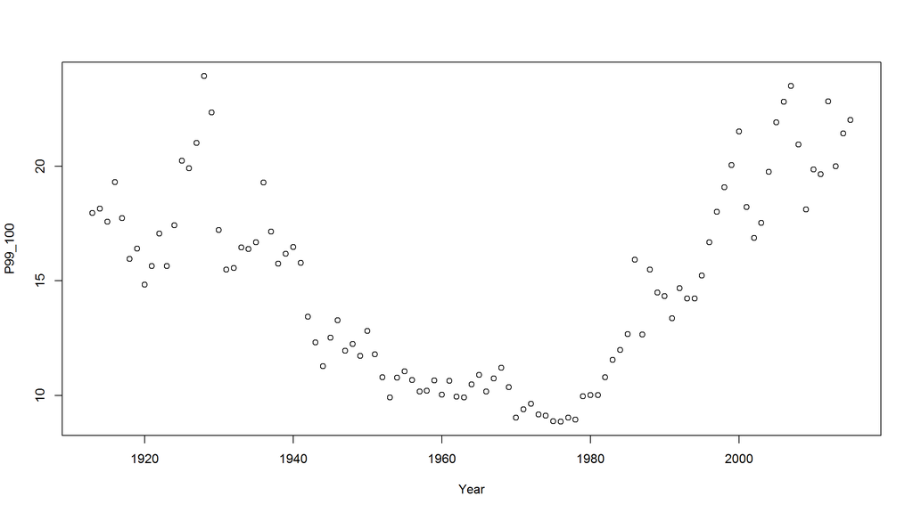

```r
# plot(x = US.top.income.shares.15$Year, y = US.top.income.shares.15$P99_100)
plot(P99_100 ~ Year, data = US.top.income.shares.15)
```

최소한의 정보를 주기 위하여 각 자료의 최대값, 최소값을 고려하여 y-축의 범위를 `ylim=c(5,25)`로 설정하고, x-축의 눈금은 비워둔다. 점들을 선으로 이어주고, 점은 다시 삼각형 모양으로 바꾼다.

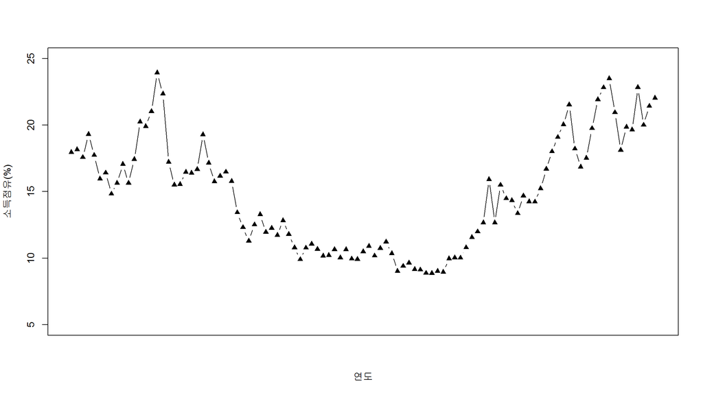

```r
plot(P99_100 ~ Year, data = US.top.income.shares.15, xlab = "연도", ylab = "소득점유(%)", ylim = c(5, 25), xaxt = "n", type = "b", pch = 17)
```

이제 x-축에는 연도를 10년 단위로 표시하고, `lines()`를 이용하여 차상위4%와 차차상위5%의 소득 점유율 변화를 함께 그린다.

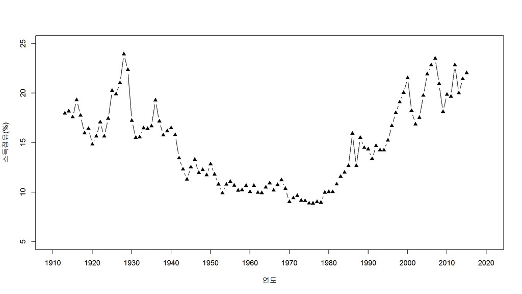

```r
plot(P99_100 ~ Year, data = US.top.income.shares.15, xlab = "연도", ylab = "소득점유(%)", xlim = c(1910, 2020), ylim = c(5, 25), xaxt = "n", type = "b", pch = 17)
axis(side = 1, at = seq(1910, 2020, by = 10), labels = seq(1910, 2020, by = 10))
```

Red added

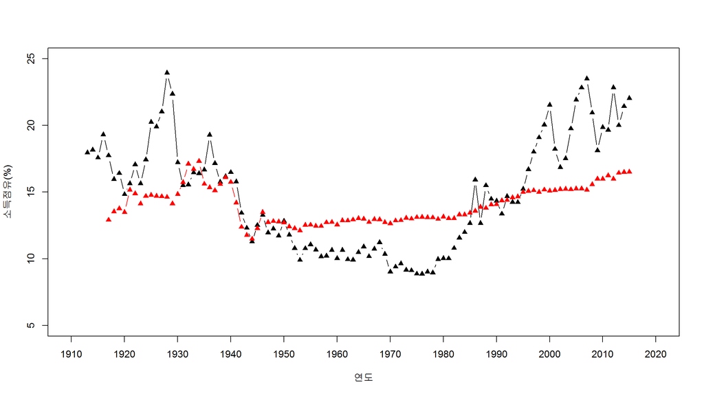

```r
plot(P99_100 ~ Year, data = US.top.income.shares.15, xlab = "연도", ylab = "소득점유(%)", xlim = c(1910, 2020), ylim = c(5, 25), xaxt = "n", type = "b", pch = 17)
axis(side = 1, at = seq(1910, 2020, by = 10), labels = seq(1910, 2020, by = 10))
lines(P95_99 ~ Year, data = US.top.income.shares.15, type = "b", pch = 17, col = "red")
```

Blue added

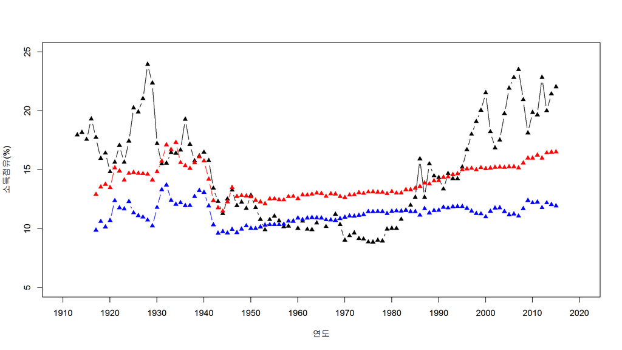

```r
plot(P99_100 ~ Year, data = US.top.income.shares.15, xlab = "연도", ylab = "소득점유(%)", xlim = c(1910, 2020), ylim = c(5, 25), xaxt = "n", type = "b", pch = 17)
axis(side = 1, at = seq(1910, 2020, by = 10), labels = seq(1910, 2020, by = 10))
lines(P95_99 ~ Year, data = US.top.income.shares.15, type = "b", pch = 17, col = "red")
lines(P90_95 ~ Year, data = US.top.income.shares.15, type = "b", pch = 17, col = "blue")
```

도표의 가독성을 높이기 위하여 x-축과 y-축을 가로지르는 격자를 설치한다.

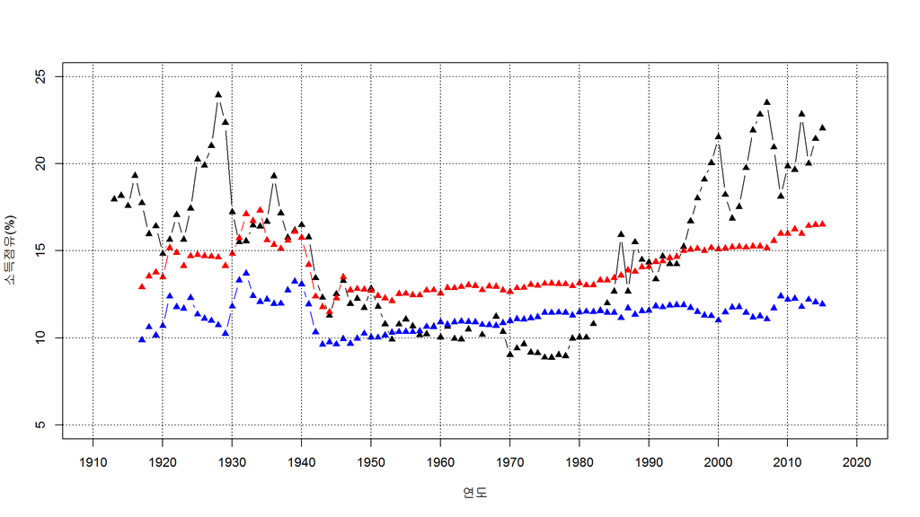

```r
plot(P99_100 ~ Year, data = US.top.income.shares.15, xlab = "연도", ylab = "소득점유(%)", xlim = c(1910, 2020), ylim = c(5, 25), xaxt = "n", type = "b", pch = 17)
axis(side = 1, at = seq(1910, 2020, by = 10), labels = seq(1910, 2020, by = 10))
lines(P95_99 ~ Year, data = US.top.income.shares.15, type = "b", pch = 17, col = "red")
lines(P90_95 ~ Year, data = US.top.income.shares.15, type = "b", pch = 17, col = "blue")
abline(h = seq(5, 25, by = 5), lty = 3)
abline(v = seq(1910, 2020, by = 10), lty = 3)
```

`TabFig2015prel.xls`의 `Table 0` 시트에 나와 있는 정보를 활용하여 범례를 만든다.

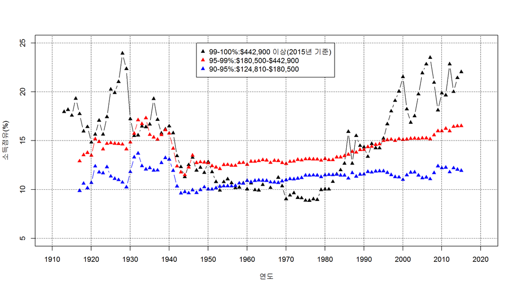

```r
plot(P99_100 ~ Year, data = US.top.income.shares.15, xlab = "연도", ylab = "소득점유(%)", xlim = c(1910, 2020), ylim = c(5,25), xaxt = "n", type = "b", pch = 17)
axis(side = 1, at = seq(1910, 2020, by = 10), labels = seq(1910, 2020, by = 10))
lines(P95_99 ~ Year, data = US.top.income.shares.15, type = "b", pch = 17, col = "red")
lines(P90_95 ~ Year, data = US.top.income.shares.15, type = "b", pch = 17, col = "blue")
abline(h = seq(5, 25, by = 5), lty = 3)
abline(v = seq(1910, 2020, by = 10), lty = 3)
legend.text <- c("99-100%:$442,900 이상(2015년 기준)", "95-99%:$180,500-$442,900", "90-95%:$124,810-$180,500")
legend(x = 1947, y = 25, legend = legend.text, pch = 17, col = c("black", "red", "blue"))
```

메인 타이틀을 입력하고, 상위1%의 소득점유율이 최고에 달했던 연도를 표시한다.

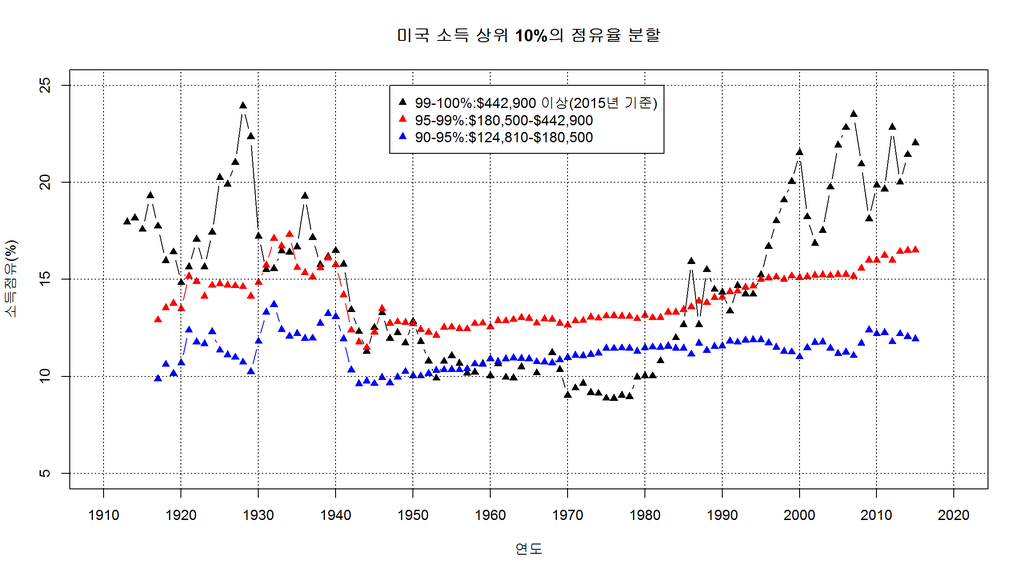

```r
plot(P99_100 ~ Year, data = US.top.income.shares.15, xlab = "연도", ylab = "소득점유(%)", xlim = c(1910, 2020), ylim = c(5,25), xaxt = "n", type = "b", pch = 17)
axis(side = 1, at = seq(1910, 2020, by = 10), labels = seq(1910, 2020, by = 10))
lines(P95_99 ~ Year, data = US.top.income.shares.15, type = "b", pch = 17, col = "red")
lines(P90_95 ~ Year, data = US.top.income.shares.15, type = "b", pch = 17, col = "blue")
abline(h = seq(5, 25, by = 5), lty = 3)
abline(v = seq(1910, 2020, by = 10), lty = 3)
legend.text <- c("99-100%:$442,900 이상(2015년 기준)", "95-99%:$180,500-$442,900", "90-95%:$124,810-$180,500")
legend(x = 1947, y = 25, legend = legend.text, pch = 17, col = c("black", "red", "blue"))
main.title <- "미국 소득 상위 10%의 점유율 분할"
title(main = main.title)
```

상위 1%의 점유가 정점이었을 때

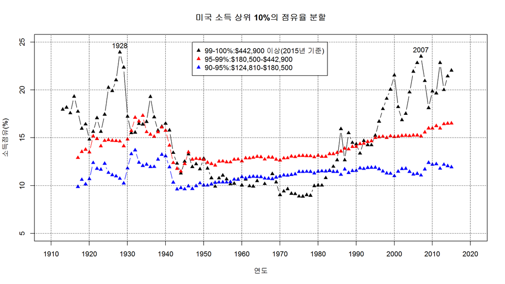

```r
plot(P99_100 ~ Year, data = US.top.income.shares.15, xlab = "연도", ylab = "소득점유(%)", xlim = c(1910, 2020), ylim = c(5,25), xaxt = "n", type = "b", pch = 17)
axis(side = 1, at = seq(1910, 2020, by = 10), labels = seq(1910, 2020, by = 10))
lines(P95_99 ~ Year, data = US.top.income.shares.15, type = "b", pch = 17, col = "red")
lines(P90_95 ~ Year, data = US.top.income.shares.15, type = "b", pch = 17, col = "blue")
abline(h = seq(5, 25, by = 5), lty = 3)
abline(v = seq(1910, 2020, by = 10), lty = 3)
legend.text <- c("99-100%:$442,900 이상(2015년 기준)", "95-99%:$180,500-$442,900", "90-95%:$124,810-$180,500")
legend(x = 1947, y = 25, legend = legend.text, pch = 17, col = c("black", "red", "blue"))
main.title <- "미국 소득 상위 10%의 점유율 분할"
title(main = main.title)
y.1928 <- US.top.income.shares.15$P99_100[US.top.income.shares.15$Year == 1928]
y.2007 <- US.top.income.shares.15$P99_100[US.top.income.shares.15$Year == 2007]
text(x = c(1928, 2007), y = c(y.1928, y.2007), labels = c(1928, 2007), pos = 3)
```

역사적으로 각 시기를 어떻게 부르고 있는지 텍스트를 추가한다.

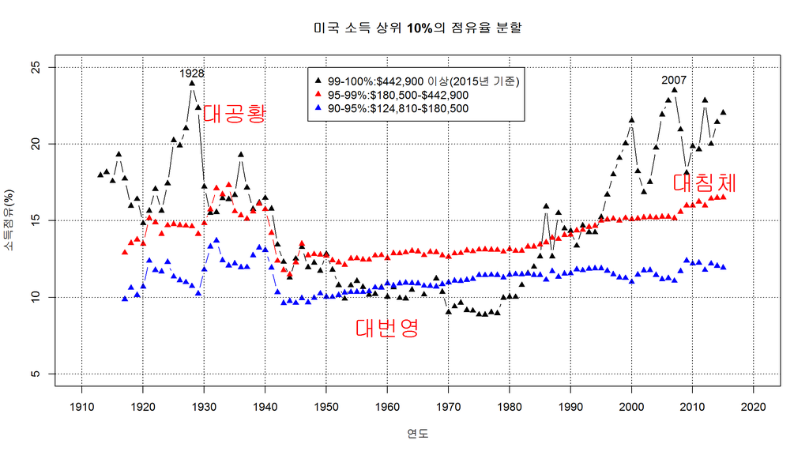

```r
plot(P99_100 ~ Year, data = US.top.income.shares.15, xlab = "연도", ylab = "소득점유(%)", xlim = c(1910, 2020), ylim = c(5,25), xaxt = "n", type = "b", pch = 17)
axis(side = 1, at = seq(1910, 2020, by = 10), labels = seq(1910, 2020, by = 10))
lines(P95_99 ~ Year, data = US.top.income.shares.15, type = "b", pch = 17, col = "red")
lines(P90_95 ~ Year, data = US.top.income.shares.15, type = "b", pch = 17, col = "blue")
abline(h = seq(5, 25, by = 5), lty = 3)
abline(v = seq(1910, 2020, by = 10), lty = 3)
legend.text <- c("99-100%:$442,900 이상(2015년 기준)", "95-99%:$180,500-$442,900", "90-95%:$124,810-$180,500")
legend(x = 1947, y = 25, legend = legend.text, pch = 17, col = c("black", "red", "blue"))
main.title <- "미국 소득 상위 10%의 점유율 분할"
title(main = main.title)
y.1928 <- US.top.income.shares.15$P99_100[US.top.income.shares.15$Year == 1928]
y.2007 <- US.top.income.shares.15$P99_100[US.top.income.shares.15$Year == 2007]
text(x = c(1928, 2007), y = c(y.1928, y.2007), labels = c(1928, 2007), pos = 3)
times.label <- c("대공황", "대번영", "대침체")
text(x = c(1935, 1960, 2012), y = c(22, 8, 17.5), label = times.label, cex = 2.0, col = "red")
```

## ggplot

### Data Reshaping

- `reshape2` 패키지를 이용하여 wide format 을 long format 으로

```r
library(reshape2)
data.1_10 <- US.top.income.shares.15[c("Year", "P99_100", "P95_99", "P90_95")]
data.1_10.melt <- melt(data.1_10, id.vars = "Year", measure.vars = c("P99_100", "P95_99", "P90_95"), variable.name = "Percentiles", value.name = "Share")
str(data.1_10.melt)
```

```
## 'data.frame':    309 obs. of  3 variables:
##  $ Year       : int  1913 1914 1915 1916 1917 1918 1919 1920 1921 1922 ...
##  $ Percentiles: Factor w/ 3 levels "P99_100","P95_99",..: 1 1 1 1 1 1 1 1 1 1 ...
##  $ Share      : num  18 18.2 17.6 19.3 17.7 ...
```

골격 그리기

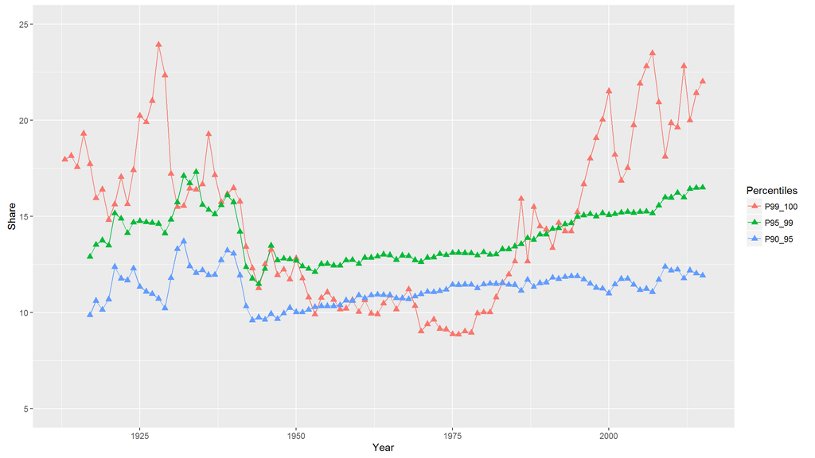

```r
library(ggplot2)
(g0 <- ggplot(data.1_10.melt, aes(x = Year, y = Share, colour = Percentiles)) +
  geom_line(na.rm = TRUE) +
  geom_point(shape = 24, aes(fill = Percentiles), size = 2, na.rm = TRUE) +
  ylim(5, 25))
```

theme_bw() 적용

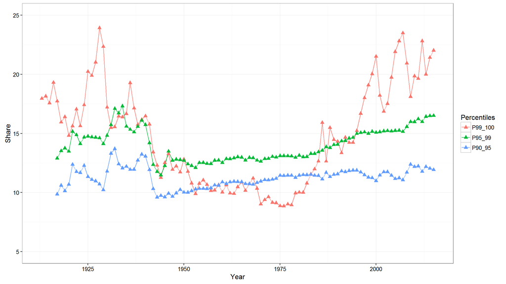

```r
(g1 <- g0 +
  theme_bw())
```

```r
#(g1 <- g0 + theme_classic())
#(g1 <- g0 + theme_minimal())
#(g1 <- g0 + theme_grey())
```

격자 설정

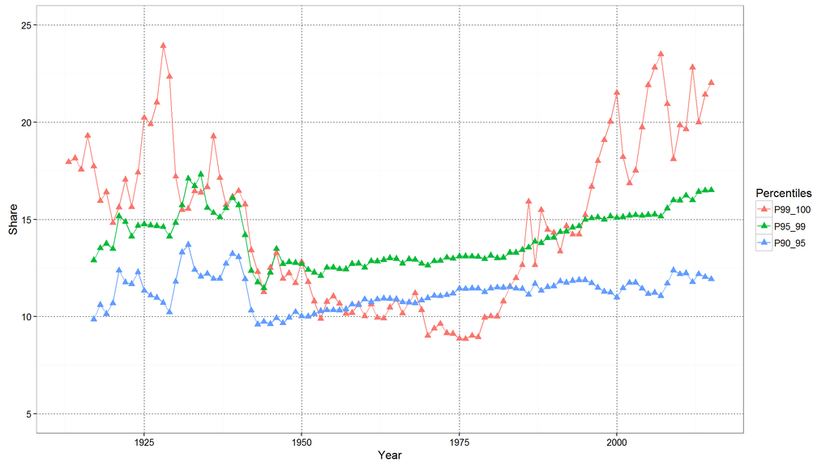

```r
(g2 <- g1 +
   theme(panel.grid.major = element_line(linetype = "dashed", colour = "black")))
```

x-축 눈금 위치 설정

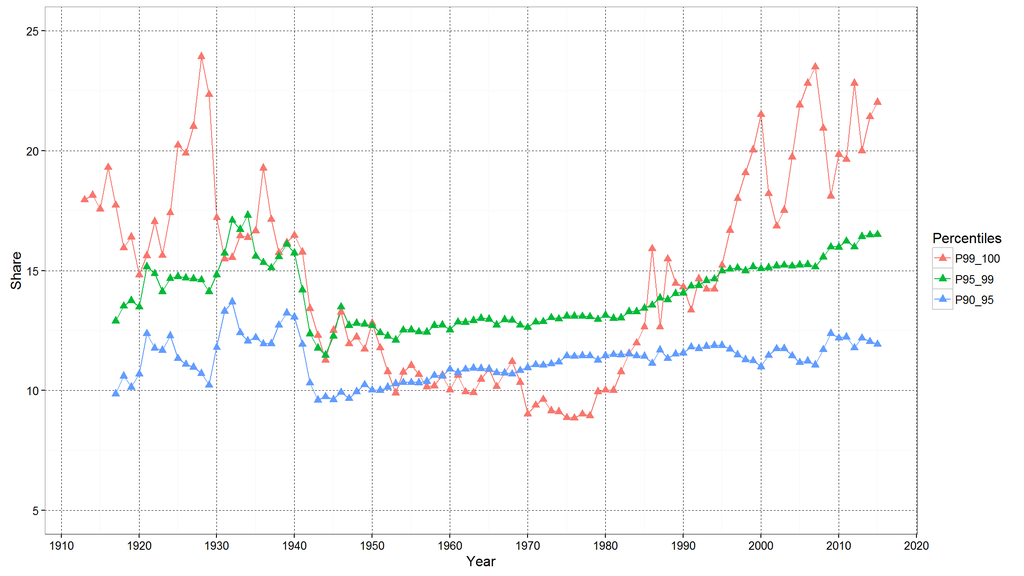

```r
(g3 <- g2 +
  scale_x_continuous(breaks = seq(1910, 2020, by = 10)))
```

### 한글 정보 입력

한글 테마 sourcing

```r
source("./theme_kr.R")
ls()
```

```
##  [1] "data.1_10"               "data.1_10.melt"
##  [3] "g0"                      "g1"
##  [5] "g10"                     "g11"
##  [7] "g12"                     "g13"
##  [9] "g2"                      "g3"
## [11] "g4"                      "g5"
## [13] "g6"                      "g7"
## [15] "g8"                      "g9"
## [17] "legend.text"             "main.title"
## [19] "theme.kr"                "times.label"
## [21] "US.top.income.shares.15" "v.names"
## [23] "y.1928"                  "y.2007"
```

한글 테마 적용, x-축과 y-축의 라벨 수정

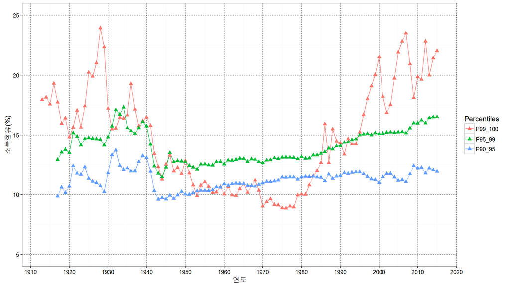

```r
(g4 <- g3 +
   theme.kr +
   xlab("연도") +
   ylab("소득점유(%)"))
```

전체 제목 추가

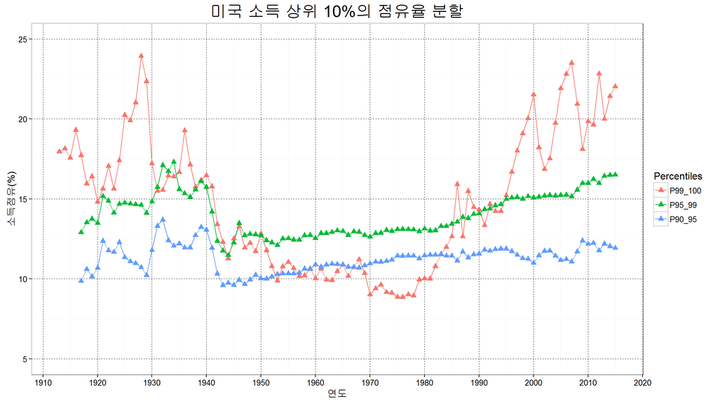

```r
(g5 <- g4 +
   ggtitle(main.title) +
   theme(plot.title = element_text(size = 20)))
```

범례 제목 수정

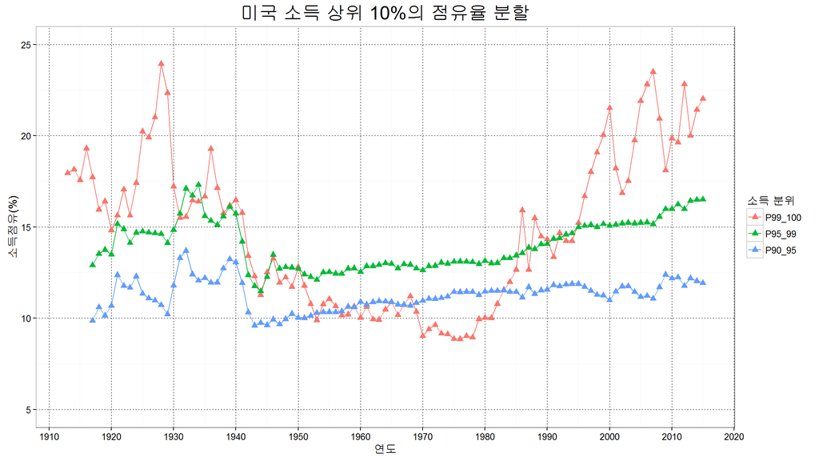

```r
(g6 <- g5 +
   labs(colour = "소득 분위", fill = "소득 분위") )
```

범례와 색깔 수정, 범례 제목 없애기

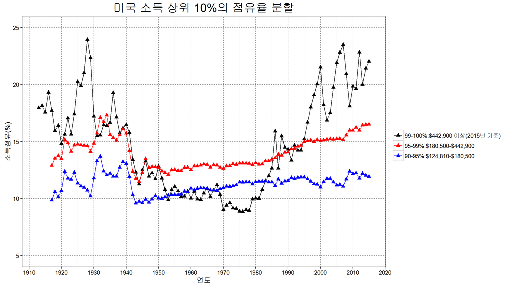

```r
(g7 <- g6 +
   scale_colour_manual(name = "", values = c("black", "red", "blue"), labels = legend.text) +
   scale_fill_manual(name = "", values = c("black", "red", "blue"), labels = legend.text))
```

범례를 안쪽으로

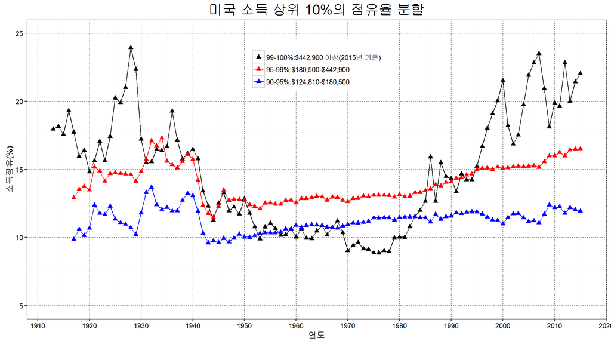

```r
(g8 <- g7 +
   theme(legend.position =  c(0.5, 0.85)))
```

colour 범례 없애기(colour 설정으로 나타나는 범례의 선 없애는 효과)

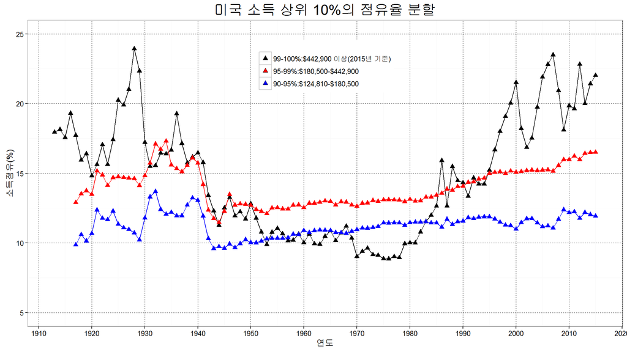

```r
#(g9 <- g8 + guides(colour = guide_legend(title=NULL), fill = guide_legend(title=NULL)))
(g9 <- g8 +
   guides(colour ="none"))
```

범례에 박스 두르고, 빈 제목 자리 없애기

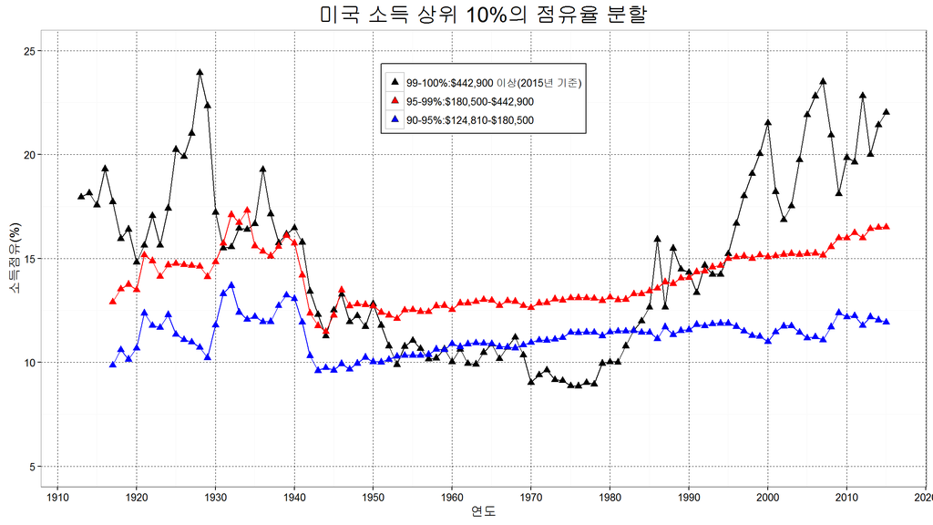

```r
(g10 <- g9 +
   theme(legend.title = element_blank(), legend.background = element_rect(fill = "white", colour = "black")))
```

범례 항목 박스 없애기

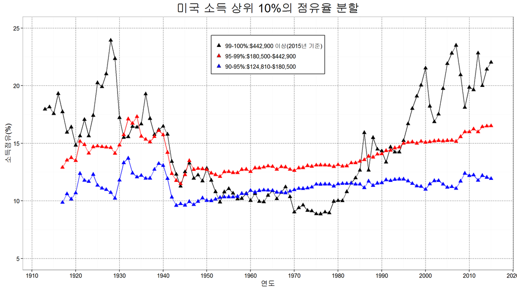

```r
(g11 <- g10 +
   theme(legend.key = element_blank()))
```

역사상 고점 시기

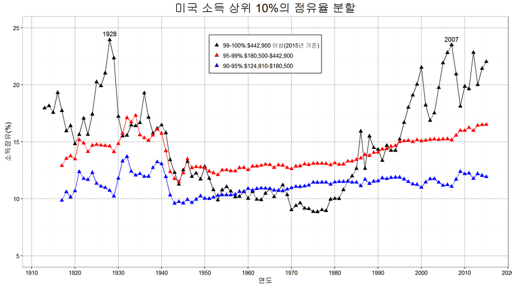

```r
(g12 <- g11 +
   annotate("text", x = c(1928, 2007), y = c(24.5, 24), label = c(1928, 2007)))
```

시대적 특징 텍스트 입력

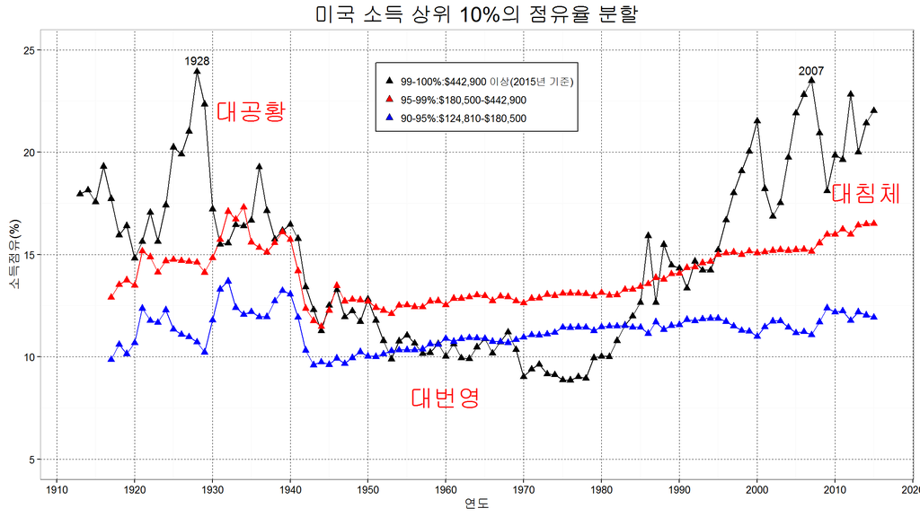

```r
(g13 <- g12 +
  annotate("text", x = c(1935, 1960, 2014), y = c(22, 8, 18), label = times.label, colour = "red", family = "HCR Dotum LVT", size = 8))
```